# MEPS verification demo

This is a quick demonstration of how to do point verication with harp using ensembles from IFSENS and an experimental AROME-Arctic ensemble.

The data for daily forecasts initiated at 00 UTC 8 - 31 March 2018 have already been interpolated to points at WMO stations and can be found under `/lustre/storeB/project/nwp/alertness/wp4/harp/FCTABLE` and the observations can be found under `/lustre/storeB/project/nwp/alertness/wp4/harp/OBSTABLE`.

To begin we attach the harp and tidyverse packages and set our data directory. If you do not have tidyverse, it is sufficient to just attach `dplyr`.

```r
library(harp)
library(tidyverse)
data_dir <- "/lustre/storeB/project/nwp/alertness/wp4/harp/"
```

# READ forecast

Now let’s read in the MEPS data for 2m temperature using `read_point_forecast()`

```r
t2m_fcst
```

```
## ● AAEPS
## # A tibble: 105,672 x 18
##    fcdate              validdate           leadtime   SID parameter
##    <dttm>              <dttm>                 <int> <int> <chr>
##  1 2018-03-08 00:00:00 2018-03-08 00:00:00        0  1001 T2m
##  2 2018-03-08 00:00:00 2018-03-08 00:00:00        0  1002 T2m
##  3 2018-03-08 00:00:00 2018-03-08 00:00:00        0  1003 T2m
##  4 2018-03-08 00:00:00 2018-03-08 00:00:00        0  1004 T2m
##  5 2018-03-08 00:00:00 2018-03-08 00:00:00        0  1006 T2m
##  6 2018-03-08 00:00:00 2018-03-08 00:00:00        0  1007 T2m
##  7 2018-03-08 00:00:00 2018-03-08 00:00:00        0  1008 T2m
##  8 2018-03-08 00:00:00 2018-03-08 00:00:00        0  1009 T2m
##  9 2018-03-08 00:00:00 2018-03-08 00:00:00        0  1010 T2m
## 10 2018-03-08 00:00:00 2018-03-08 00:00:00        0  1011 T2m
## # … with 105,662 more rows, and 13 more variables: reference_runs_mbr000 <dbl>,
## #   reference_runs_mbr001 <dbl>, reference_runs_mbr002 <dbl>,
## #   reference_runs_mbr003 <dbl>, reference_runs_mbr004 <dbl>,
## #   reference_runs_mbr005 <dbl>, reference_runs_mbr006 <dbl>,
## #   reference_runs_mbr007 <dbl>, reference_runs_mbr008 <dbl>,
## #   reference_runs_mbr009 <dbl>, reference_runs_mbr010 <dbl>, fcst_cycle <chr>,
## #   units <chr>
##
## ● IFSENS
## # A tibble: 99,144 x 57
##    fcdate              validdate           leadtime   SID ECEPS50_mbr000
##    <dttm>              <dttm>                 <int> <int>          <dbl>
##  1 2018-03-08 00:00:00 2018-03-08 00:00:00        0  1001           271.
##  2 2018-03-08 00:00:00 2018-03-08 00:00:00        0  1002           263.
##  3 2018-03-08 00:00:00 2018-03-08 00:00:00        0  1003           260.
##  4 2018-03-08 00:00:00 2018-03-08 00:00:00        0  1004           259.
##  5 2018-03-08 00:00:00 2018-03-08 00:00:00        0  1006           257.
##  6 2018-03-08 00:00:00 2018-03-08 00:00:00        0  1007           259.
##  7 2018-03-08 00:00:00 2018-03-08 00:00:00        0  1008           257.
##  8 2018-03-08 00:00:00 2018-03-08 00:00:00        0  1009           262.
##  9 2018-03-08 00:00:00 2018-03-08 00:00:00        0  1010           267.
## 10 2018-03-08 00:00:00 2018-03-08 00:00:00        0  1011           258.
## # … with 99,134 more rows, and 52 more variables: ECEPS50_mbr001 <dbl>,
## #   ECEPS50_mbr002 <dbl>, ECEPS50_mbr003 <dbl>, ECEPS50_mbr004 <dbl>,
## #   ECEPS50_mbr005 <dbl>, ECEPS50_mbr006 <dbl>, ECEPS50_mbr007 <dbl>,
## #   ECEPS50_mbr008 <dbl>, ECEPS50_mbr009 <dbl>, ECEPS50_mbr010 <dbl>,
## #   ECEPS50_mbr011 <dbl>, ECEPS50_mbr012 <dbl>, ECEPS50_mbr013 <dbl>,
## #   ECEPS50_mbr014 <dbl>, ECEPS50_mbr015 <dbl>, ECEPS50_mbr016 <dbl>,
## #   ECEPS50_mbr017 <dbl>, ECEPS50_mbr018 <dbl>, ECEPS50_mbr019 <dbl>,
## #   ECEPS50_mbr020 <dbl>, ECEPS50_mbr021 <dbl>, ECEPS50_mbr022 <dbl>,
## #   ECEPS50_mbr023 <dbl>, ECEPS50_mbr024 <dbl>, ECEPS50_mbr025 <dbl>,
## #   ECEPS50_mbr026 <dbl>, ECEPS50_mbr027 <dbl>, ECEPS50_mbr028 <dbl>,
## #   ECEPS50_mbr029 <dbl>, ECEPS50_mbr030 <dbl>, ECEPS50_mbr031 <dbl>,
## #   ECEPS50_mbr032 <dbl>, ECEPS50_mbr033 <dbl>, ECEPS50_mbr034 <dbl>,
## #   ECEPS50_mbr035 <dbl>, ECEPS50_mbr036 <dbl>, ECEPS50_mbr037 <dbl>,
## #   ECEPS50_mbr038 <dbl>, ECEPS50_mbr039 <dbl>, ECEPS50_mbr040 <dbl>,
## #   ECEPS50_mbr041 <dbl>, ECEPS50_mbr042 <dbl>, ECEPS50_mbr043 <dbl>,
## #   ECEPS50_mbr044 <dbl>, ECEPS50_mbr045 <dbl>, ECEPS50_mbr046 <dbl>,
## #   ECEPS50_mbr047 <dbl>, ECEPS50_mbr048 <dbl>, ECEPS50_mbr049 <dbl>,
## #   ECEPS50_mbr050 <dbl>, fcst_cycle <chr>, units <chr>
```

# READ obs

Now read the 2m temperarure observations using `read_point_obs()`

```r
t2m_obs
```

```
## # A tibble: 1,998,955 x 7
##    validdate             SID   lon   lat  elev   T2m units
##    <dttm>              <int> <dbl> <dbl> <dbl> <dbl> <chr>
##  1 2018-03-08 00:00:00  1001 -8.67  70.9     9  272. K
##  2 2018-03-08 00:00:00  1002 16.2   80.1     7  257. K
##  3 2018-03-08 00:00:00  1003 15.5   77.0    11  258. K
##  4 2018-03-08 00:00:00  1006 22.8   78.3    13  257. K
##  5 2018-03-08 00:00:00  1007 11.9   78.9     8  259. K
##  6 2018-03-08 00:00:00  1008 15.5   78.2    27  257. K
##  7 2018-03-08 00:00:00  1009 25.0   80.7     6  262. K
##  8 2018-03-08 00:00:00  1010 16.1   69.3    13  266. K
##  9 2018-03-08 00:00:00  1015 17.8   69.6    14  264. K
## 10 2018-03-08 00:00:00  1016 28.9   78.9    13  256. K
## # … with 1,998,945 more rows
```

Maybe we want both forecast and observations in $^\circ C$ instead of K. We can do this by using a `scale` function:

```r
t2m_fcst <- scale_point_forecast(t2m_fcst, -273.15, new_units = "degC")
t2m_obs <- scale_point_obs(t2m_obs, T2m, -273.15, new_units = "degC")
t2m_fcst
```

```
## ● AAEPS
## # A tibble: 105,672 x 18
##    fcdate              validdate           leadtime   SID parameter fcst_cycle
##    <dttm>              <dttm>                 <int> <int> <chr>     <chr>
##  1 2018-03-08 00:00:00 2018-03-08 00:00:00        0  1001 T2m       00
##  2 2018-03-08 00:00:00 2018-03-08 00:00:00        0  1002 T2m       00
##  3 2018-03-08 00:00:00 2018-03-08 00:00:00        0  1003 T2m       00
##  4 2018-03-08 00:00:00 2018-03-08 00:00:00        0  1004 T2m       00
##  5 2018-03-08 00:00:00 2018-03-08 00:00:00        0  1006 T2m       00
##  6 2018-03-08 00:00:00 2018-03-08 00:00:00        0  1007 T2m       00
##  7 2018-03-08 00:00:00 2018-03-08 00:00:00        0  1008 T2m       00
##  8 2018-03-08 00:00:00 2018-03-08 00:00:00        0  1009 T2m       00
##  9 2018-03-08 00:00:00 2018-03-08 00:00:00        0  1010 T2m       00
## 10 2018-03-08 00:00:00 2018-03-08 00:00:00        0  1011 T2m       00
## # … with 105,662 more rows, and 12 more variables: units <chr>,
## #   reference_runs_mbr000 <dbl>, reference_runs_mbr001 <dbl>,
## #   reference_runs_mbr002 <dbl>, reference_runs_mbr003 <dbl>,
## #   reference_runs_mbr004 <dbl>, reference_runs_mbr005 <dbl>,
## #   reference_runs_mbr006 <dbl>, reference_runs_mbr007 <dbl>,
## #   reference_runs_mbr008 <dbl>, reference_runs_mbr009 <dbl>,
## #   reference_runs_mbr010 <dbl>
##
## ● IFSENS
## # A tibble: 99,144 x 57
##    fcdate              validdate           leadtime   SID fcst_cycle units
##    <dttm>              <dttm>                 <int> <int> <chr>      <chr>
##  1 2018-03-08 00:00:00 2018-03-08 00:00:00        0  1001 00         degC
##  2 2018-03-08 00:00:00 2018-03-08 00:00:00        0  1002 00         degC
##  3 2018-03-08 00:00:00 2018-03-08 00:00:00        0  1003 00         degC
##  4 2018-03-08 00:00:00 2018-03-08 00:00:00        0  1004 00         degC
##  5 2018-03-08 00:00:00 2018-03-08 00:00:00        0  1006 00         degC
##  6 2018-03-08 00:00:00 2018-03-08 00:00:00        0  1007 00         degC
##  7 2018-03-08 00:00:00 2018-03-08 00:00:00        0  1008 00         degC
##  8 2018-03-08 00:00:00 2018-03-08 00:00:00        0  1009 00         degC
##  9 2018-03-08 00:00:00 2018-03-08 00:00:00        0  1010 00         degC
## 10 2018-03-08 00:00:00 2018-03-08 00:00:00        0  1011 00         degC
## # … with 99,134 more rows, and 51 more variables: ECEPS50_mbr000 <dbl>,
## #   ECEPS50_mbr001 <dbl>, ECEPS50_mbr002 <dbl>, ECEPS50_mbr003 <dbl>,
## #   ECEPS50_mbr004 <dbl>, ECEPS50_mbr005 <dbl>, ECEPS50_mbr006 <dbl>,
## #   ECEPS50_mbr007 <dbl>, ECEPS50_mbr008 <dbl>, ECEPS50_mbr009 <dbl>,
## #   ECEPS50_mbr010 <dbl>, ECEPS50_mbr011 <dbl>, ECEPS50_mbr012 <dbl>,
## #   ECEPS50_mbr013 <dbl>, ECEPS50_mbr014 <dbl>, ECEPS50_mbr015 <dbl>,
## #   ECEPS50_mbr016 <dbl>, ECEPS50_mbr017 <dbl>, ECEPS50_mbr018 <dbl>,
## #   ECEPS50_mbr019 <dbl>, ECEPS50_mbr020 <dbl>, ECEPS50_mbr021 <dbl>,
## #   ECEPS50_mbr022 <dbl>, ECEPS50_mbr023 <dbl>, ECEPS50_mbr024 <dbl>,
## #   ECEPS50_mbr025 <dbl>, ECEPS50_mbr026 <dbl>, ECEPS50_mbr027 <dbl>,
## #   ECEPS50_mbr028 <dbl>, ECEPS50_mbr029 <dbl>, ECEPS50_mbr030 <dbl>,
## #   ECEPS50_mbr031 <dbl>, ECEPS50_mbr032 <dbl>, ECEPS50_mbr033 <dbl>,
## #   ECEPS50_mbr034 <dbl>, ECEPS50_mbr035 <dbl>, ECEPS50_mbr036 <dbl>,
## #   ECEPS50_mbr037 <dbl>, ECEPS50_mbr038 <dbl>, ECEPS50_mbr039 <dbl>,
## #   ECEPS50_mbr040 <dbl>, ECEPS50_mbr041 <dbl>, ECEPS50_mbr042 <dbl>,
## #   ECEPS50_mbr043 <dbl>, ECEPS50_mbr044 <dbl>, ECEPS50_mbr045 <dbl>,
## #   ECEPS50_mbr046 <dbl>, ECEPS50_mbr047 <dbl>, ECEPS50_mbr048 <dbl>,
## #   ECEPS50_mbr049 <dbl>, ECEPS50_mbr050 <dbl>
```

```r
t2m_obs
```

```
## # A tibble: 1,998,955 x 7
##    validdate             SID   lon   lat units  elev     T2m
##    <dttm>              <int> <dbl> <dbl> <chr> <dbl>   <dbl>
##  1 2018-03-08 00:00:00  1001 -8.67  70.9 degC      9  -0.950
##  2 2018-03-08 00:00:00  1002 16.2   80.1 degC      7 -16.2
##  3 2018-03-08 00:00:00  1003 15.5   77.0 degC     11 -15.2
##  4 2018-03-08 00:00:00  1006 22.8   78.3 degC     13 -16.4
##  5 2018-03-08 00:00:00  1007 11.9   78.9 degC      8 -14.5
##  6 2018-03-08 00:00:00  1008 15.5   78.2 degC     27 -16.5
##  7 2018-03-08 00:00:00  1009 25.0   80.7 degC      6 -11.4
##  8 2018-03-08 00:00:00  1010 16.1   69.3 degC     13  -7.35
##  9 2018-03-08 00:00:00  1015 17.8   69.6 degC     14  -9.45
## 10 2018-03-08 00:00:00  1016 28.9   78.9 degC     13 -16.8
## # … with 1,998,945 more rows
```

# JOIN

Now we join the forecasts and observations so that each row has a forecast and an observation. Rows where there are no observations are discarded.

```r
t2m_fcst <- join_to_fcst(t2m_fcst, t2m_obs)
t2m_fcst
```

```
## ● AAEPS
## # A tibble: 80,262 x 22
##    fcdate              validdate           leadtime   SID parameter fcst_cycle
##    <dttm>              <dttm>                 <int> <int> <chr>     <chr>
##  1 2018-03-08 00:00:00 2018-03-08 00:00:00        0  1001 T2m       00
##  2 2018-03-08 00:00:00 2018-03-08 00:00:00        0  1002 T2m       00
##  3 2018-03-08 00:00:00 2018-03-08 00:00:00        0  1003 T2m       00
##  4 2018-03-08 00:00:00 2018-03-08 00:00:00        0  1006 T2m       00
##  5 2018-03-08 00:00:00 2018-03-08 00:00:00        0  1007 T2m       00
##  6 2018-03-08 00:00:00 2018-03-08 00:00:00        0  1008 T2m       00
##  7 2018-03-08 00:00:00 2018-03-08 00:00:00        0  1009 T2m       00
##  8 2018-03-08 00:00:00 2018-03-08 00:00:00        0  1010 T2m       00
##  9 2018-03-08 00:00:00 2018-03-08 00:00:00        0  1015 T2m       00
## 10 2018-03-08 00:00:00 2018-03-08 00:00:00        0  1016 T2m       00
## # … with 80,252 more rows, and 16 more variables: units <chr>,
## #   reference_runs_mbr000 <dbl>, reference_runs_mbr001 <dbl>,
## #   reference_runs_mbr002 <dbl>, reference_runs_mbr003 <dbl>,
## #   reference_runs_mbr004 <dbl>, reference_runs_mbr005 <dbl>,
## #   reference_runs_mbr006 <dbl>, reference_runs_mbr007 <dbl>,
## #   reference_runs_mbr008 <dbl>, reference_runs_mbr009 <dbl>,
## #   reference_runs_mbr010 <dbl>, lon <dbl>, lat <dbl>, elev <dbl>, T2m <dbl>
##
## ● IFSENS
## # A tibble: 73,914 x 61
##    fcdate              validdate           leadtime   SID fcst_cycle units
##    <dttm>              <dttm>                 <int> <int> <chr>      <chr>
##  1 2018-03-08 00:00:00 2018-03-08 00:00:00        0  1001 00         degC
##  2 2018-03-08 00:00:00 2018-03-08 00:00:00        0  1002 00         degC
##  3 2018-03-08 00:00:00 2018-03-08 00:00:00        0  1003 00         degC
##  4 2018-03-08 00:00:00 2018-03-08 00:00:00        0  1006 00         degC
##  5 2018-03-08 00:00:00 2018-03-08 00:00:00        0  1007 00         degC
##  6 2018-03-08 00:00:00 2018-03-08 00:00:00        0  1008 00         degC
##  7 2018-03-08 00:00:00 2018-03-08 00:00:00        0  1009 00         degC
##  8 2018-03-08 00:00:00 2018-03-08 00:00:00        0  1010 00         degC
##  9 2018-03-08 00:00:00 2018-03-08 00:00:00        0  1015 00         degC
## 10 2018-03-08 00:00:00 2018-03-08 00:00:00        0  1016 00         degC
## # … with 73,904 more rows, and 55 more variables: ECEPS50_mbr000 <dbl>,
## #   ECEPS50_mbr001 <dbl>, ECEPS50_mbr002 <dbl>, ECEPS50_mbr003 <dbl>,
## #   ECEPS50_mbr004 <dbl>, ECEPS50_mbr005 <dbl>, ECEPS50_mbr006 <dbl>,
## #   ECEPS50_mbr007 <dbl>, ECEPS50_mbr008 <dbl>, ECEPS50_mbr009 <dbl>,
## #   ECEPS50_mbr010 <dbl>, ECEPS50_mbr011 <dbl>, ECEPS50_mbr012 <dbl>,
## #   ECEPS50_mbr013 <dbl>, ECEPS50_mbr014 <dbl>, ECEPS50_mbr015 <dbl>,
## #   ECEPS50_mbr016 <dbl>, ECEPS50_mbr017 <dbl>, ECEPS50_mbr018 <dbl>,
## #   ECEPS50_mbr019 <dbl>, ECEPS50_mbr020 <dbl>, ECEPS50_mbr021 <dbl>,
## #   ECEPS50_mbr022 <dbl>, ECEPS50_mbr023 <dbl>, ECEPS50_mbr024 <dbl>,
## #   ECEPS50_mbr025 <dbl>, ECEPS50_mbr026 <dbl>, ECEPS50_mbr027 <dbl>,
## #   ECEPS50_mbr028 <dbl>, ECEPS50_mbr029 <dbl>, ECEPS50_mbr030 <dbl>,
## #   ECEPS50_mbr031 <dbl>, ECEPS50_mbr032 <dbl>, ECEPS50_mbr033 <dbl>,
## #   ECEPS50_mbr034 <dbl>, ECEPS50_mbr035 <dbl>, ECEPS50_mbr036 <dbl>,
## #   ECEPS50_mbr037 <dbl>, ECEPS50_mbr038 <dbl>, ECEPS50_mbr039 <dbl>,
## #   ECEPS50_mbr040 <dbl>, ECEPS50_mbr041 <dbl>, ECEPS50_mbr042 <dbl>,
## #   ECEPS50_mbr043 <dbl>, ECEPS50_mbr044 <dbl>, ECEPS50_mbr045 <dbl>,
## #   ECEPS50_mbr046 <dbl>, ECEPS50_mbr047 <dbl>, ECEPS50_mbr048 <dbl>,
## #   ECEPS50_mbr049 <dbl>, ECEPS50_mbr050 <dbl>, lon <dbl>, lat <dbl>,
## #   elev <dbl>, T2m <dbl>
```

# VERIFY

We are now ready to verify, with `ens_verify()`

```r
t2m_verif <- ens_verify(t2m_fcst, T2m)
```

```r
t2m_verif
```

```
## $ens_summary_scores
## # A tibble: 34 x 12
##    mname leadtime num_cases mean_bias  stde  rmse spread spread_skill_ratio
##    <chr>    <int>     <int>     <dbl> <dbl> <dbl>  <dbl>              <dbl>
##  1 AAEPS        0      4604     1.11   3.18  3.36  1.51               0.450
##  2 AAEPS        3      4444     1.33   3.43  3.68  1.34               0.365
##  3 AAEPS        6      4892     1.08   3.32  3.49  1.32               0.379
##  4 AAEPS        9      4710     0.680  2.27  2.37  1.10               0.465
##  5 AAEPS       12      4883     0.489  1.74  1.80  0.978              0.542
##  6 AAEPS       15      4722     0.445  1.69  1.74  0.978              0.561
##  7 AAEPS       18      4898     0.494  2.55  2.60  1.16               0.446
##  8 AAEPS       21      4670     0.851  3.30  3.41  1.29               0.378
##  9 AAEPS       24      4604     1.24   3.78  3.98  1.37               0.344
## 10 AAEPS       27      4445     1.54   4.09  4.37  1.39               0.319
## # … with 24 more rows, and 4 more variables: rank_histogram <list>, crps <dbl>,
## #   crps_potential <dbl>, crps_reliability <dbl>
##
## $ens_threshold_scores
## # A tibble: 0 x 0
##
## $det_summary_scores
## # A tibble: 1,054 x 9
##    mname member leadtime sub_model      num_cases     bias  rmse   mae  stde
##    <chr> <chr>     <int> <chr>              <int>    <dbl> <dbl> <dbl> <dbl>
##  1 AAEPS mbr000        0 reference_runs      4604  0.650    3.21  2.25  3.14
##  2 AAEPS mbr000        3 reference_runs      4444  0.877    3.46  2.40  3.35
##  3 AAEPS mbr000        6 reference_runs      4892  0.659    3.33  2.32  3.26
##  4 AAEPS mbr000        9 reference_runs      4710  0.198    2.32  1.59  2.31
##  5 AAEPS mbr000       12 reference_runs      4883 -0.00730  1.77  1.27  1.77
##  6 AAEPS mbr000       15 reference_runs      4722 -0.0814   1.76  1.28  1.76
##  7 AAEPS mbr000       18 reference_runs      4898 -0.0433   2.65  1.97  2.65
##  8 AAEPS mbr000       21 reference_runs      4670  0.297    3.42  2.49  3.41
##  9 AAEPS mbr000       24 reference_runs      4604  0.679    3.92  2.83  3.86
## 10 AAEPS mbr000       27 reference_runs      4445  0.990    4.27  3.04  4.15
## # … with 1,044 more rows
##
## attr(,"parameter")
## [1] "T2m"
## attr(,"start_date")
## [1] "2018030800"
## attr(,"end_date")
## [1] "2018033100"
## attr(,"num_stations")
## [1] 208
```

# PLOT

We can now plot scores using `plot_point_verif()`

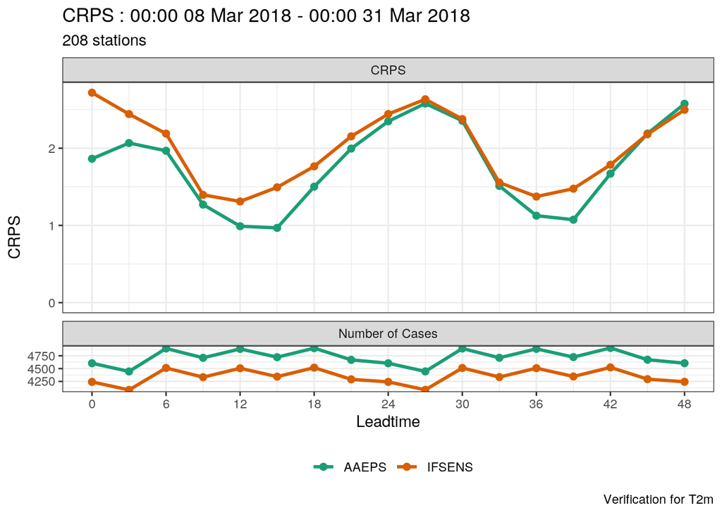

```r
plot_point_verif(t2m_verif, crps)
```

Here it is clear that a different number of cases have been used for AAEPS than IFSENS. This often happens when comparing forecast models and for a fair comparison the same cases should be used for both models. harp can fix this by using the `common_cases()` function:

```r
t2m_verif <- ens_verify(common_cases(t2m_fcst), T2m)
```

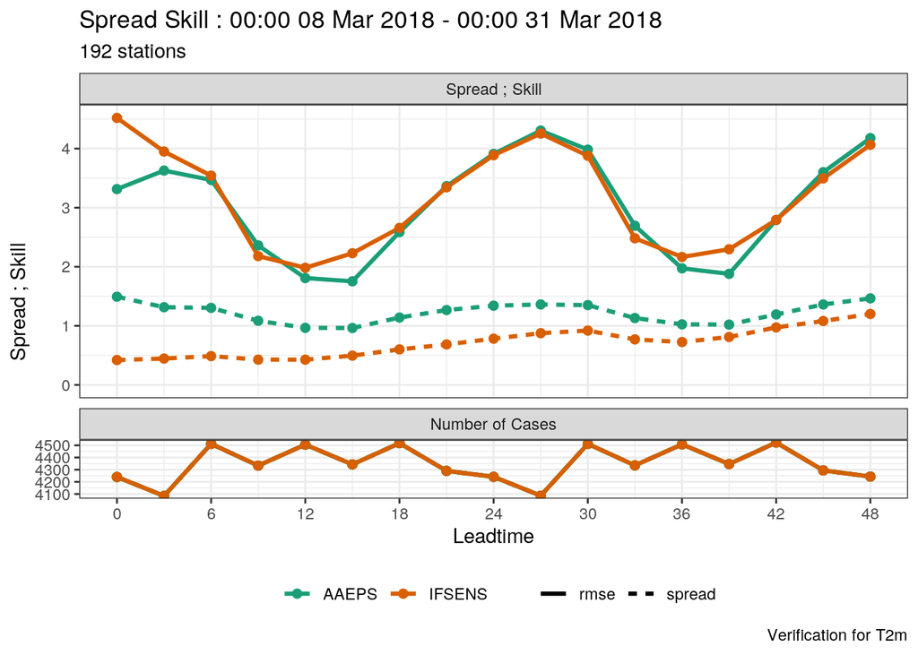

```r
plot_point_verif(t2m_verif, crps)
plot_point_verif(t2m_verif, spread_skill)
```

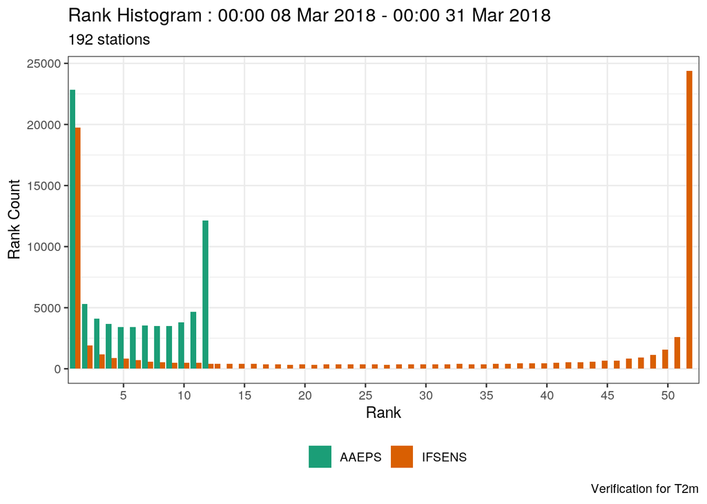

```r
plot_point_verif(t2m_verif, rank_histogram)
```

Rank histograms for ensembles with a different number of members are lopsided - so we can fix that with the `rank_is_relative` switch, and can also normalize so that the ideal column height is 1.

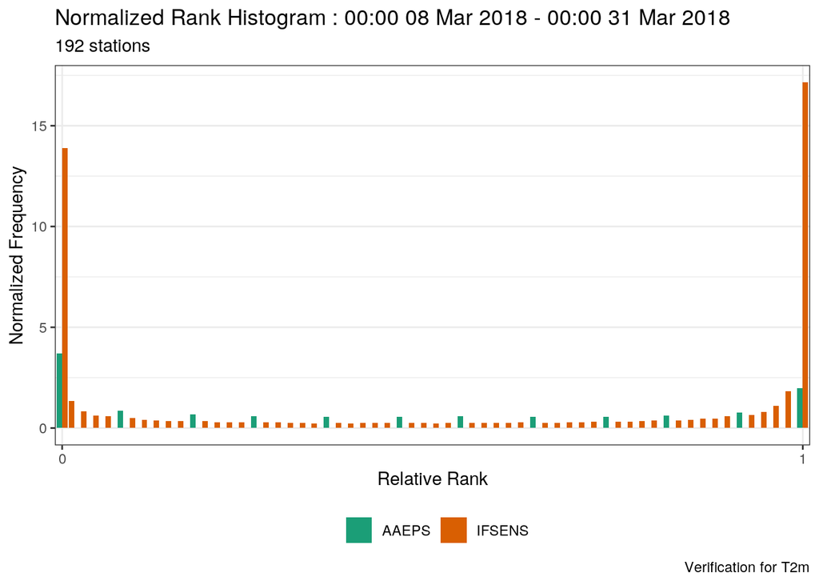

```r
plot_point_verif(
  t2m_verif, normalized_rank_histogram, rank_is_relative = TRUE
)
```

To verify for categorical scores, just add some thresholds

```r
t2m_verif <- ens_verify(common_cases(t2m_fcst), T2m, thresholds = seq(-10, 10, 5))
```

```r
t2m_verif
```

```
## $ens_summary_scores
## # A tibble: 34 x 12
##    mname leadtime num_cases mean_bias  stde  rmse spread spread_skill_ratio
##    <chr>    <int>     <int>     <dbl> <dbl> <dbl>  <dbl>              <dbl>
##  1 AAEPS        0      4240     1.09   3.13  3.31  1.49               0.450
##  2 AAEPS        3      4084     1.32   3.38  3.63  1.32               0.362
##  3 AAEPS        6      4512     1.10   3.29  3.47  1.30               0.376
##  4 AAEPS        9      4333     0.710  2.25  2.36  1.09               0.460
##  5 AAEPS       12      4506     0.507  1.74  1.81  0.966              0.534
##  6 AAEPS       15      4343     0.464  1.69  1.75  0.963              0.549
##  7 AAEPS       18      4518     0.515  2.53  2.59  1.14               0.441
##  8 AAEPS       21      4290     0.857  3.25  3.37  1.27               0.377
##  9 AAEPS       24      4241     1.22   3.72  3.91  1.34               0.343
## 10 AAEPS       27      4086     1.53   4.03  4.31  1.36               0.316
## # … with 24 more rows, and 4 more variables: rank_histogram <list>, crps <dbl>,
## #   crps_potential <dbl>, crps_reliability <dbl>
##
## $ens_threshold_scores
## # A tibble: 170 x 18
##    mname leadtime threshold fair_brier_score sample_climatolo… bss_ref_climatol…
##    <chr>    <int>     <dbl>            <dbl>             <dbl>             <dbl>
##  1 AAEPS        0       -10           0.0983             0.564             0.564
##  2 AAEPS        3       -10           0.0964             0.533             0.533
##  3 AAEPS        6       -10           0.102              0.554             0.554
##  4 AAEPS        9       -10           0.0827             0.762             0.762
##  5 AAEPS       12       -10           0.0462             0.869             0.869
##  6 AAEPS       15       -10           0.0459             0.862             0.862
##  7 AAEPS       18       -10           0.0931             0.728             0.728
##  8 AAEPS       21       -10           0.121              0.630             0.630
##  9 AAEPS       24       -10           0.130              0.576             0.576
## 10 AAEPS       27       -10           0.130              0.542             0.542
## # … with 160 more rows, and 12 more variables: num_cases_total <int>,
## #   num_cases_observed <int>, num_cases_forecast <int>, brier_score <dbl>,
## #   brier_skill_score <dbl>, brier_score_reliability <dbl>,
## #   brier_score_resolution <dbl>, brier_score_uncertainty <dbl>,
## #   reliability <list>, roc <list>, roc_area <dbl>, economic_value <list>
##
## $det_summary_scores
## # A tibble: 1,054 x 9
##    mname member leadtime sub_model      num_cases     bias  rmse   mae  stde
##    <chr> <chr>     <int> <chr>              <int>    <dbl> <dbl> <dbl> <dbl>
##  1 AAEPS mbr000        0 reference_runs      4240  0.648    3.16  2.22  3.09
##  2 AAEPS mbr000        3 reference_runs      4084  0.882    3.43  2.38  3.31
##  3 AAEPS mbr000        6 reference_runs      4512  0.682    3.30  2.30  3.23
##  4 AAEPS mbr000        9 reference_runs      4333  0.228    2.31  1.58  2.29
##  5 AAEPS mbr000       12 reference_runs      4506  0.00957  1.77  1.26  1.77
##  6 AAEPS mbr000       15 reference_runs      4343 -0.0625   1.75  1.27  1.75
##  7 AAEPS mbr000       18 reference_runs      4518 -0.0137   2.61  1.94  2.61
##  8 AAEPS mbr000       21 reference_runs      4290  0.315    3.34  2.44  3.33
##  9 AAEPS mbr000       24 reference_runs      4241  0.663    3.82  2.76  3.76
## 10 AAEPS mbr000       27 reference_runs      4086  0.982    4.17  2.98  4.06
## # … with 1,044 more rows
##
## attr(,"parameter")
## [1] "T2m"
## attr(,"start_date")
## [1] "2018030800"
## attr(,"end_date")
## [1] "2018033100"
## attr(,"num_stations")
## [1] 192
```

# SAVE

You can also save your verification data so you can explore plots on an app in your internet browser. Here we will save into `tempdir()` which is a temporary directory that will be erased when you close you R session. Usually you would save to somewhere more permanent…

```r
save_point_verif(t2m_verif, tempdir())
```

```
## Saving point verification scores to:
## /tmp/RtmptzdezR/harpPointVerif.harp.T2m.harp.2018030800-2018033100.harp.AAEPS.model.IFSENS.rds
```

You’ll see that the file name is a little convoluted, but this helps the app get information from the file name.

# EXPLORE

You start the app with `shiny_plot_point_verif(<dir>)`

```r
shiny_plot_point_verif(tempdir())
```

# Precipitation

Typically model precipitation is accumulated from the start of the model run. This is still the case when we interpolate the data. However, when we read in the interpolated data we can accumulate to different periods using AccPcp*h, where you replace the * with the number of hours of accumulation time.

```r
pcp_6h <- read_point_forecast(
  2018030800,
  2018033100,
  c("AAEPS", "IFSENS"),
  "EPS",
  "AccPcp6h",
  by            = "1d",
  file_path     = file.path(data_dir, "FCTABLE"),
  file_template = list(
    AAEPS  = aaeps_template,
    IFSENS = ifsens_template
  )
) %>%
  common_cases() %>%
  join_to_fcst(
    read_point_obs(
      first_validdate(.),
      last_validdate(.),
      "AccPcp6h",
      obs_path = file.path(data_dir, "OBSTABLE")
    )
  )
```

```r
pcp_6h_verif <- ens_verify(
  pcp_6h, AccPcp6h, thresholds = c(0.125, 0.25, 0.5, 1, 2, 4, 8)
)
```

```r
save_point_verif(pcp_6h_verif, tempdir())
```

```
## Saving point verification scores to:
## /tmp/RtmptzdezR/harpPointVerif.harp.AccPcp6h.harp.2018030800-2018033000.harp.AAEPS.model.IFSENS.rds
```

Do the same for 12h precipitation

```r
read_point_forecast(
  2018030800,
  2018033100,
  c("AAEPS", "IFSENS"),
  "EPS",
  "AccPcp12h",
  by            = "1d",
  file_path     = file.path(data_dir, "FCTABLE"),
  file_template = list(
    AAEPS  = aaeps_template,
    IFSENS = ifsens_template
  )
) %>%
  common_cases() %>%
  join_to_fcst(
    read_point_obs(
      first_validdate(.),
      last_validdate(.),
      "AccPcp12h",
      obs_path = file.path(data_dir, "OBSTABLE")
    )
  ) %>%
  ens_verify(
    AccPcp12h, thresholds = c(0.125, 0.25, 0.5, 1, 2, 4, 8)
  ) %>%
  save_point_verif(tempdir())
```

## Grouped verification.

The verification can also be split into groups using the `groupings` argument. By default, the data are already by grouped by lead time, but we could for example group by location. harp comes with a data frame of stations grouped by region / geographic characteristic taken from the “monitor”. So we simply need to join this data frame to our forecast / observations data. We need to “force” join as `join_to_fcst()` is designed to join observations to forecasts, so the units are checked - here we don’t want to do this.

```r
t2m_grouped <- join_to_fcst(
  common_cases(t2m_fcst),
  station_groups,
  force_join = TRUE
)
```

```r
t2m_grouped
```

```
## ● AAEPS
## # A tibble: 313,782 x 23
##    fcdate              validdate           leadtime   SID parameter fcst_cycle
##    <dttm>              <dttm>                 <int> <int> <chr>     <chr>
##  1 2018-03-08 00:00:00 2018-03-08 00:00:00        0  1001 T2m       00
##  2 2018-03-08 00:00:00 2018-03-08 00:00:00        0  1001 T2m       00
##  3 2018-03-08 00:00:00 2018-03-08 00:00:00        0  1001 T2m       00
##  4 2018-03-08 00:00:00 2018-03-08 00:00:00        0  1001 T2m       00
##  5 2018-03-08 00:00:00 2018-03-08 00:00:00        0  1001 T2m       00
##  6 2018-03-08 00:00:00 2018-03-08 00:00:00        0  1002 T2m       00
##  7 2018-03-08 00:00:00 2018-03-08 00:00:00        0  1002 T2m       00
##  8 2018-03-08 00:00:00 2018-03-08 00:00:00        0  1002 T2m       00
##  9 2018-03-08 00:00:00 2018-03-08 00:00:00        0  1002 T2m       00
## 10 2018-03-08 00:00:00 2018-03-08 00:00:00        0  1002 T2m       00
## # … with 313,772 more rows, and 17 more variables: units <chr>,
## #   reference_runs_mbr000 <dbl>, reference_runs_mbr001 <dbl>,
## #   reference_runs_mbr002 <dbl>, reference_runs_mbr003 <dbl>,
## #   reference_runs_mbr004 <dbl>, reference_runs_mbr005 <dbl>,
## #   reference_runs_mbr006 <dbl>, reference_runs_mbr007 <dbl>,
## #   reference_runs_mbr008 <dbl>, reference_runs_mbr009 <dbl>,
## #   reference_runs_mbr010 <dbl>, lon <dbl>, lat <dbl>, elev <dbl>, T2m <dbl>,
## #   group <chr>
##
## ● IFSENS
## # A tibble: 313,782 x 62
##    fcdate              validdate           leadtime   SID fcst_cycle units
##    <dttm>              <dttm>                 <int> <int> <chr>      <chr>
##  1 2018-03-08 00:00:00 2018-03-08 00:00:00        0  1001 00         degC
##  2 2018-03-08 00:00:00 2018-03-08 00:00:00        0  1001 00         degC
##  3 2018-03-08 00:00:00 2018-03-08 00:00:00        0  1001 00         degC
##  4 2018-03-08 00:00:00 2018-03-08 00:00:00        0  1001 00         degC
##  5 2018-03-08 00:00:00 2018-03-08 00:00:00        0  1001 00         degC
##  6 2018-03-08 00:00:00 2018-03-08 00:00:00        0  1002 00         degC
##  7 2018-03-08 00:00:00 2018-03-08 00:00:00        0  1002 00         degC
##  8 2018-03-08 00:00:00 2018-03-08 00:00:00        0  1002 00         degC
##  9 2018-03-08 00:00:00 2018-03-08 00:00:00        0  1002 00         degC
## 10 2018-03-08 00:00:00 2018-03-08 00:00:00        0  1002 00         degC
## # … with 313,772 more rows, and 56 more variables: ECEPS50_mbr000 <dbl>,
## #   ECEPS50_mbr001 <dbl>, ECEPS50_mbr002 <dbl>, ECEPS50_mbr003 <dbl>,
## #   ECEPS50_mbr004 <dbl>, ECEPS50_mbr005 <dbl>, ECEPS50_mbr006 <dbl>,
## #   ECEPS50_mbr007 <dbl>, ECEPS50_mbr008 <dbl>, ECEPS50_mbr009 <dbl>,
## #   ECEPS50_mbr010 <dbl>, ECEPS50_mbr011 <dbl>, ECEPS50_mbr012 <dbl>,
## #   ECEPS50_mbr013 <dbl>, ECEPS50_mbr014 <dbl>, ECEPS50_mbr015 <dbl>,
## #   ECEPS50_mbr016 <dbl>, ECEPS50_mbr017 <dbl>, ECEPS50_mbr018 <dbl>,
## #   ECEPS50_mbr019 <dbl>, ECEPS50_mbr020 <dbl>, ECEPS50_mbr021 <dbl>,
## #   ECEPS50_mbr022 <dbl>, ECEPS50_mbr023 <dbl>, ECEPS50_mbr024 <dbl>,
## #   ECEPS50_mbr025 <dbl>, ECEPS50_mbr026 <dbl>, ECEPS50_mbr027 <dbl>,
## #   ECEPS50_mbr028 <dbl>, ECEPS50_mbr029 <dbl>, ECEPS50_mbr030 <dbl>,
## #   ECEPS50_mbr031 <dbl>, ECEPS50_mbr032 <dbl>, ECEPS50_mbr033 <dbl>,
## #   ECEPS50_mbr034 <dbl>, ECEPS50_mbr035 <dbl>, ECEPS50_mbr036 <dbl>,
## #   ECEPS50_mbr037 <dbl>, ECEPS50_mbr038 <dbl>, ECEPS50_mbr039 <dbl>,
## #   ECEPS50_mbr040 <dbl>, ECEPS50_mbr041 <dbl>, ECEPS50_mbr042 <dbl>,
## #   ECEPS50_mbr043 <dbl>, ECEPS50_mbr044 <dbl>, ECEPS50_mbr045 <dbl>,
## #   ECEPS50_mbr046 <dbl>, ECEPS50_mbr047 <dbl>, ECEPS50_mbr048 <dbl>,
## #   ECEPS50_mbr049 <dbl>, ECEPS50_mbr050 <dbl>, lon <dbl>, lat <dbl>,
## #   elev <dbl>, T2m <dbl>, group <chr>
```

As you can see, the `group` column has been added. Now we can verify with `groupings = c("leadtime", "group")`

```r
t2m_grouped_verif <- ens_verify(
  t2m_grouped, T2m, groupings = c("leadtime", "group"),
  thresholds = seq(-10, 5, 5)
)
```

Now when we plot. something weird happens…

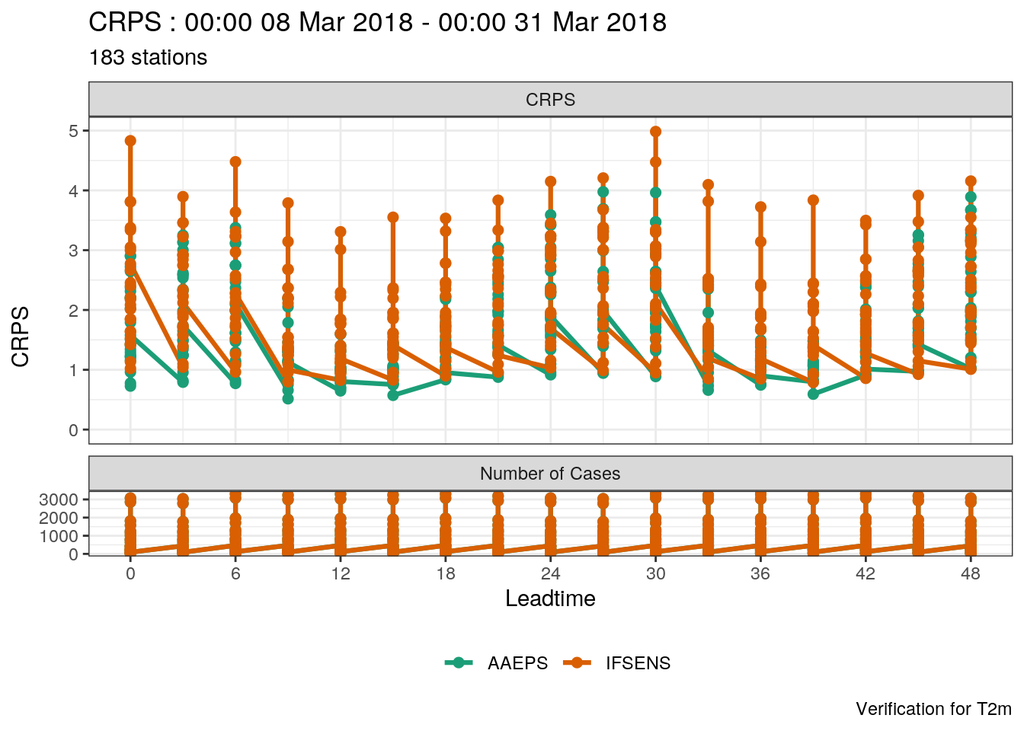

```r
plot_point_verif(t2m_grouped_verif, crps)
```

This is because all of the groups are being plotted on top of each other, so we need to separate them out using `facet_by` and / or `filter_by`

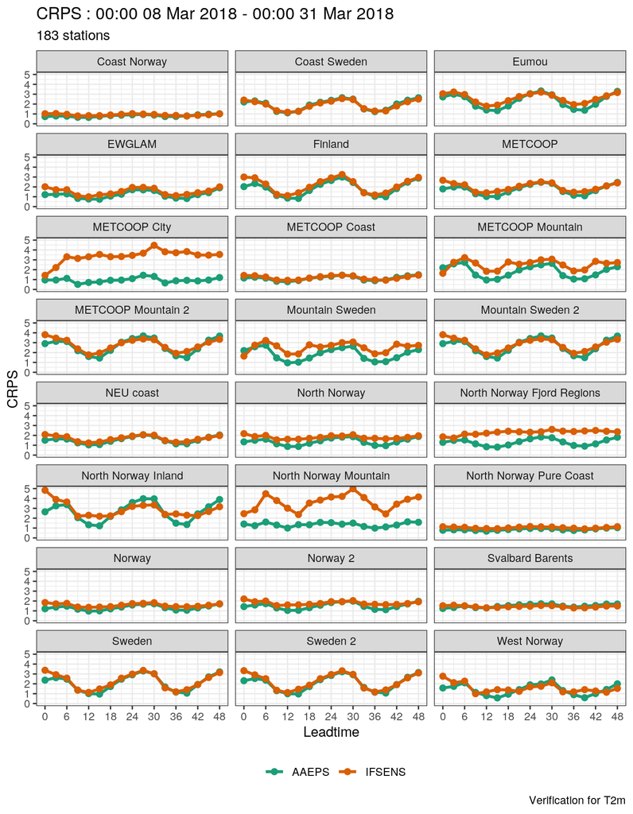

```r
plot_point_verif(t2m_grouped_verif, crps, facet_by = vars(group))
```

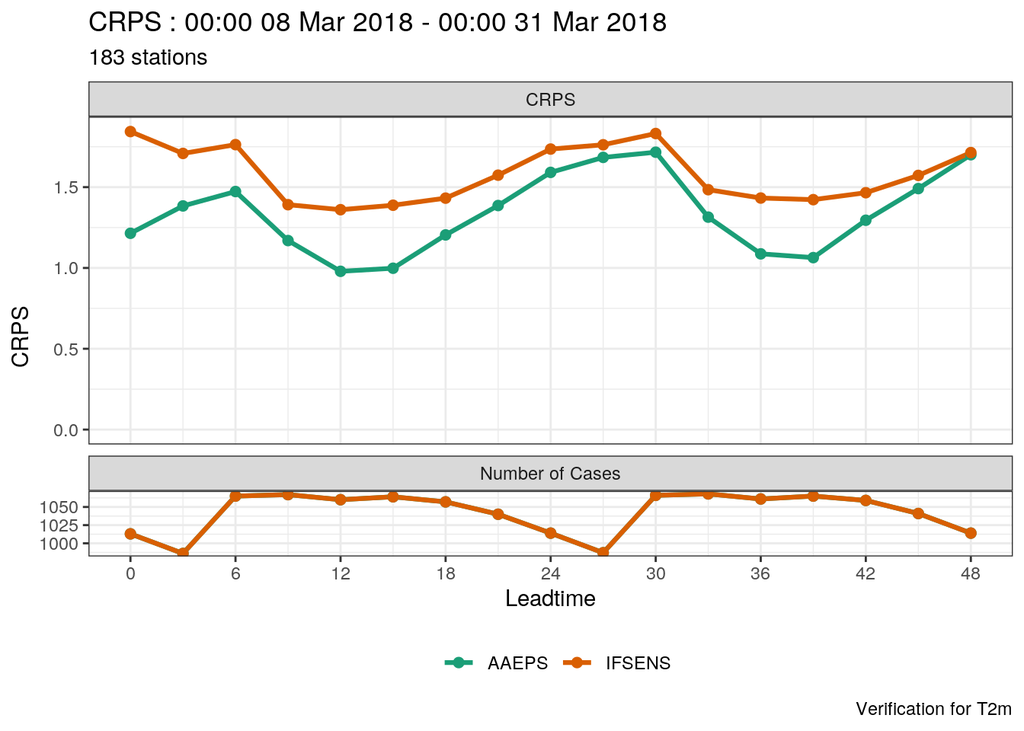

```r
plot_point_verif(t2m_grouped_verif, crps, filter_by = vars(group == "Norway"))
```

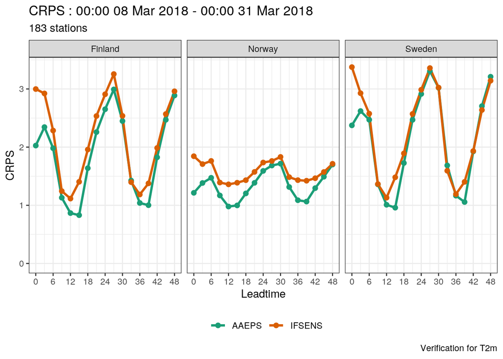

```r
plot_point_verif(
  t2m_grouped_verif, crps, facet_by = vars(group),
  filter_by = vars(group %in% c("Norway", "Sweden", "Finland"))
)
```

```r
save_point_verif(t2m_grouped_verif, tempdir())
```

```
## Saving point verification scores to:
## /tmp/RtmptzdezR/harpPointVerif.harp.T2m.harp.2018030800-2018033100.harp.AAEPS.model.IFSENS.rds
```

# DETERMINISTIC VERIFICATION

Deterministic verification works in exactly the same way as the EPS verification - you follow the exact same workflow: READ -> READ -> JOIN -> VERIFY

```r
fcst_t2m_det <- read_point_forecast(
  2018030800,
  2018033100,
  c("arome_arctic", "MEPS_det"),
  "det",
  "T2m",
  by        = "1d",
  file_path = file.path(data_dir, "FCTABLE")
) %>%
  common_cases() %>%
  scale_point_forecast(-273.15, new_units = "degC")

obs_t2m <- read_point_obs(
  first_validdate(fcst_t2m_det),
  last_validdate(fcst_t2m_det),
  "T2m",
  stations = pull_stations(fcst_t2m_det),
  obs_path = file.path(data_dir, "OBSTABLE")
) %>%
  scale_point_obs(T2m, -273.15, new_units = "degC")

fcst_t2m_det <- join_to_fcst(fcst_t2m_det, obs_t2m)

verif_t2m_det <- det_verify(
  fcst_t2m_det,
  T2m,
  thresholds    = seq(-15, 5, 2.5)
)

verif_t2m_det
```

```
## $det_summary_scores
## # A tibble: 34 x 7
##    mname        leadtime num_cases    bias  rmse   mae  stde
##    <chr>           <int>     <int>   <dbl> <dbl> <dbl> <dbl>
##  1 arome_arctic        0      4275  0.651   2.96  2.07  2.89
##  2 arome_arctic        3      4110  0.808   3.16  2.20  3.05
##  3 arome_arctic        6      4539  0.564   3.00  2.08  2.94
##  4 arome_arctic        9      4362  0.0486  2.04  1.42  2.04
##  5 arome_arctic       12      4526 -0.140   1.58  1.15  1.57
##  6 arome_arctic       15      4364 -0.222   1.56  1.15  1.55
##  7 arome_arctic       18      4544 -0.171   2.47  1.84  2.47
##  8 arome_arctic       21      4315  0.220   3.23  2.36  3.22
##  9 arome_arctic       24      4275  0.603   3.74  2.71  3.69
## 10 arome_arctic       27      4110  0.935   4.14  2.94  4.03
## # … with 24 more rows
##
## $det_threshold_scores
## # A tibble: 306 x 40
##    mname  leadtime threshold num_cases_for_th… num_cases_for_t… num_cases_for_t…
##    <chr>     <int>     <dbl>             <dbl>            <dbl>            <dbl>
##  1 arome…        0       -15              3759             3445             3617
##  2 arome…        3       -15              3506             3172             3355
##  3 arome…        6       -15              3988             3645             3816
##  4 arome…        9       -15              4254             4156             4192
##  5 arome…       12       -15              4476             4456             4451
##  6 arome…       15       -15              4312             4297             4275
##  7 arome…       18       -15              4424             4226             4324
##  8 arome…       21       -15              4092             3745             3950
##  9 arome…       24       -15              3941             3488             3765
## 10 arome…       27       -15              3730             3193             3556
## # … with 296 more rows, and 34 more variables: cont_tab <list>,
## #   threat_score <dbl>, hit_rate <dbl>, miss_rate <dbl>,
## #   false_alarm_rate <dbl>, false_alarm_ratio <dbl>, heidke_skill_score <dbl>,
## #   pierce_skill_score <dbl>, kuiper_skill_score <dbl>, percent_correct <dbl>,
## #   frequency_bias <dbl>, equitable_threat_score <dbl>, odds_ratio <dbl>,
## #   log_odds_ratio <dbl>, odds_ratio_skill_score <dbl>,
## #   extreme_dependency_score <dbl>, symmetric_eds <dbl>,
## #   extreme_dependency_index <dbl>, symmetric_edi <dbl>,
## #   threat_score_std_error <dbl>, hit_rate_std_error <dbl>,
## #   false_alarm_rate_std_error <dbl>, false_alarm_ratio_std_error <dbl>,
## #   heidke_skill_score_std_error <dbl>, pierce_skill_score_std_error <dbl>,
## #   percent_correct_std_error <dbl>, equitable_threat_score_std_error <dbl>,
## #   log_odds_ratio_std_error <dbl>, log_odds_ratio_degrees_of_freedom <dbl>,
## #   odds_ratio_skill_score_std_error <dbl>,
## #   extreme_dependency_score_std_error <dbl>, symmetric_eds_std_error <dbl>,
## #   extreme_dependency_index_std_error <dbl>, symmetric_edi_std_error <dbl>
##
## attr(,"parameter")
## [1] "T2m"
## attr(,"start_date")
## [1] "2018030800"
## attr(,"end_date")
## [1] "2018033100"
## attr(,"num_stations")
## [1] 193
```

```r
save_point_verif(verif_t2m_det, tempdir())
```

# UPPER AIR VERIFICATION

Again, works exactly the same, except that you need to add `vertical_coordinate = "pressure` when running `read_point_forecast()` and `read_point_obs()`, and make sure to group the verification by “p”. Plotting is done with `plot_profile_verif()` and is not available yet in the app.

As upper air data were interpolated to all stations and not just upper air stations, we use the first day to find out which stations we need.

```r
fcst_t_det <- read_point_forecast(
  2018030800,
  2018030800,
  c("arome_arctic", "MEPS_det"),
  "det",
  "T",
  by                  = "1d",
  vertical_coordinate = "pressure",
  file_path           = file.path(data_dir, "FCTABLE")
) %>%
  common_cases()

obs_t <- read_point_obs(
  first_validdate(fcst_t_det),
  last_validdate(fcst_t_det),
  "T",
  vertical_coordinate = "pressure",
  stations            = pull_stations(fcst_t_det),
  obs_path            = file.path(data_dir, "OBSTABLE")
)

stations <- pull_stations(join_to_fcst(fcst_t_det, obs_t))

fcst_t_det <- read_point_forecast(
  2018030800,
  2018033100,
  c("arome_arctic", "MEPS_det"),
  "det",
  "T",
  by                  = "1d",
  stations            = stations,
  vertical_coordinate = "pressure",
  file_path           = file.path(data_dir, "FCTABLE")
) %>%
  common_cases() %>%
  scale_point_forecast(-273.15, new_units = "degC")

obs_t <- read_point_obs(
  first_validdate(fcst_t_det),
  last_validdate(fcst_t_det),
  "T",
  vertical_coordinate = "pressure",
  stations            = pull_stations(fcst_t_det),
  obs_path            = file.path(data_dir, "OBSTABLE")
) %>%
  scale_point_obs(T, -273.15, new_units = "degC")

fcst_t_det <- join_to_fcst(fcst_t_det, obs_t)

verif_t_det <- det_verify(
  fcst_t_det,
  T,
  groupings = c("leadtime", "p")
)

verif_t_det
```

```
## $det_summary_scores
## # A tibble: 312 x 8
##    mname        leadtime     p num_cases    bias  rmse   mae  stde
##    <chr>           <int> <dbl>     <int>   <dbl> <dbl> <dbl> <dbl>
##  1 arome_arctic        0    50        56 -0.405  0.806 0.608 0.702
##  2 arome_arctic        0   100        89 -0.0651 0.622 0.487 0.622
##  3 arome_arctic        0   150        86  0.0651 0.640 0.479 0.641
##  4 arome_arctic        0   200        86  0.165  0.558 0.397 0.536
##  5 arome_arctic        0   250        86  0.0137 0.497 0.396 0.499
##  6 arome_arctic        0   300        86 -0.105  0.436 0.324 0.425
##  7 arome_arctic        0   400        86 -0.0697 0.317 0.228 0.311
##  8 arome_arctic        0   500        86 -0.0538 0.264 0.183 0.260
##  9 arome_arctic        0   700        87 -0.101  0.360 0.256 0.348
## 10 arome_arctic        0   850        86 -0.0108 0.252 0.184 0.253
## # … with 302 more rows
##
## $det_threshold_scores
## # A tibble: 0 x 0
##
## attr(,"parameter")
## [1] "T"
## attr(,"start_date")
## [1] "2018030800"
## attr(,"end_date")
## [1] "2018033100"
## attr(,"num_stations")
## [1] 4
```

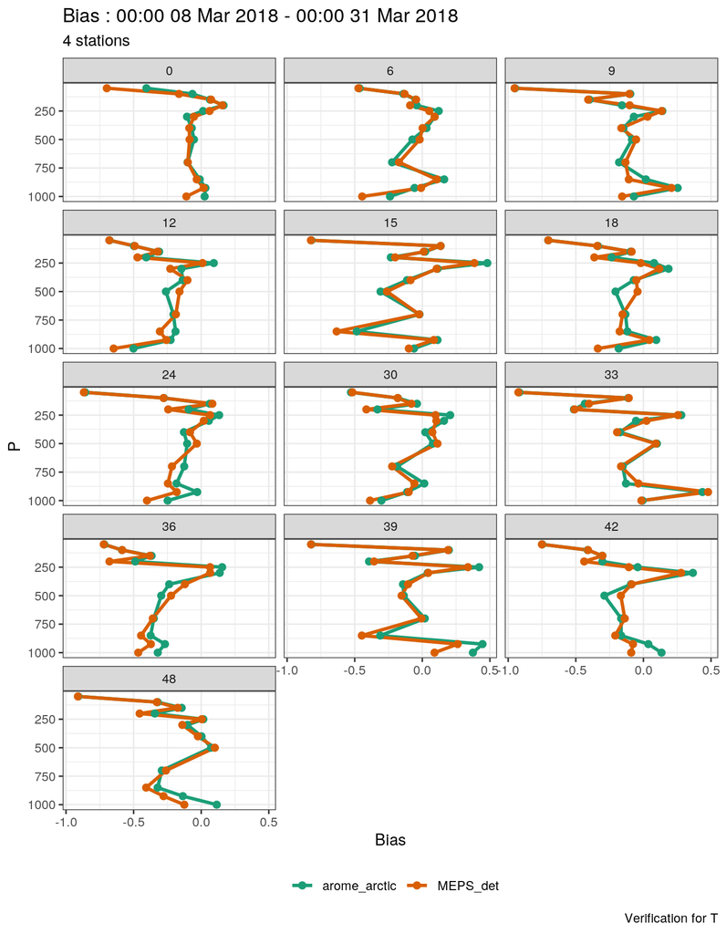

```r
plot_profile_verif(verif_t_det, bias, facet_by = vars(leadtime))
```

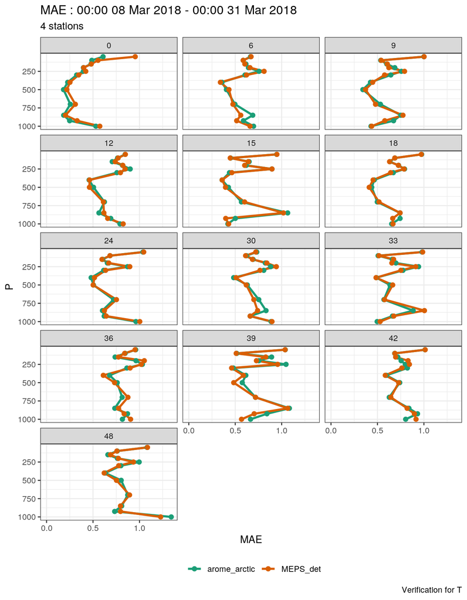

```r
plot_profile_verif(verif_t_det, mae, facet_by = vars(leadtime))
```

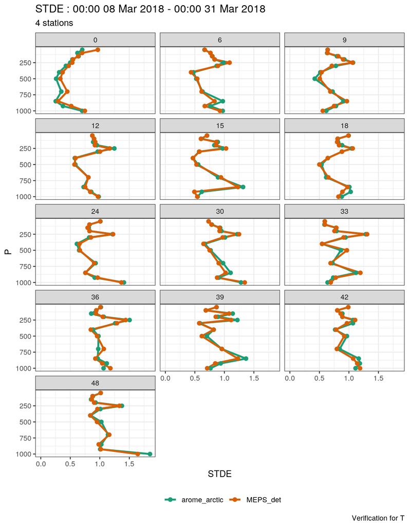

```r
plot_profile_verif(verif_t_det, stde, facet_by = vars(leadtime))
```